# Project1 My data story

Yiwen Ma

9/16/2019

A song is composed of lyrics and rythm. Both of them represent some part of the feelings from the artist. There are various type of songs, Country, Hip-Hop, Rock, R&B, etc. Regardless of the rythm, Lets see how these genres differ from each other.

- From the very begining, the lyrics data should be processed through data cleaning, removing the whitespace, stop words and some undesirable words. After that, in order to compare the difference between genres, some basic statistical findings will first be analyzed.

## How many songs released over the year?

The bar chart shows the relationship between time(decades) and number of songs in the data set. Each genre is represented by different color. The conclusion is that, Rock has a longer history than other genres, with its own debut in 1970s or even earlier. At the same time, Rock is more prolific than others. In each decade, Rock is the majority, followed by pop and metal. It is quite intristing that these excited and powerful music are more plentiful than others. Is it possible that the beat drum and rhythmic music increase the creative ithch of the artists?

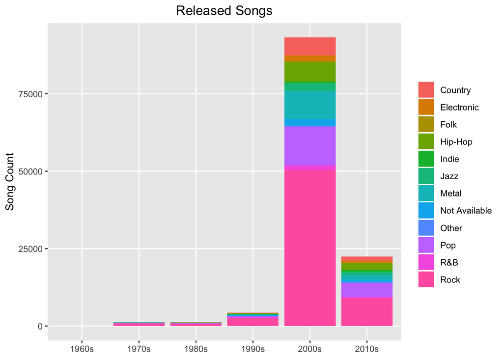

## What is the length of these songs?

An overview on the word counts of these songs. Hop-hop has the highest average word count. A resonaable explain could be that hip-hop songs always contain rap section, which make its word density much higher than other.

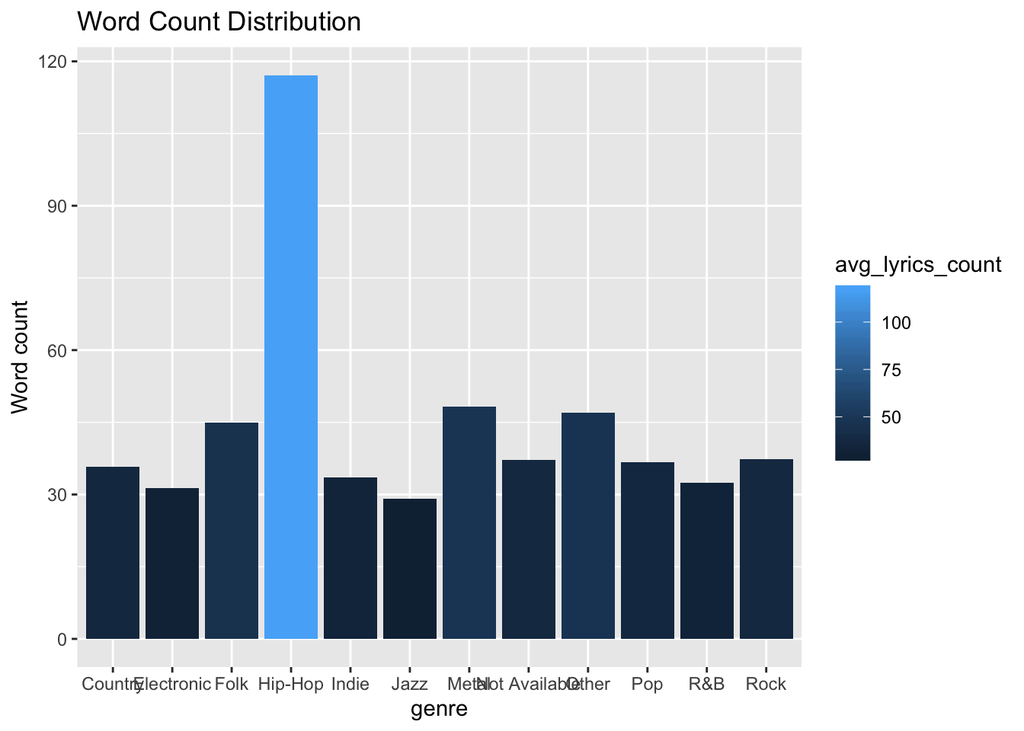

## Top 10 songs with highest word count

Songs With Highest Word Count

| song | year | genre | num_words |
| --- | --- | --- | --- |
| yes-sir-i-will | 2007 | Rock | 1449 |
| rip-vs-poet-laurette | 2012 | Hip-Hop | 778 |
| calm-down | 2014 | Hip-Hop | 756 |
| because-the-internet-screenplay-part-2 | 2013 | Hip-Hop | 710 |
| run-for-cover | 2006 | Hip-Hop | 678 |
| straight-spittin | 2006 | Hip-Hop | 676 |
| crimson-ii | 2007 | Metal | 659 |
| crimson-ii-incantation | 2006 | Metal | 652 |
| quitter | 2006 | Hip-Hop | 645 |
| magica | 2000 | Rock | 630 |

‘Yes sir i will’ from the Rock category has the highest word count. Following several hip-pop and metal, Hip-pop secure major spots in this rank, which verifies the former chart of average word count.

## General Word Frequency

Here is a worldcloud which shows the most frequent word occuring in these songs. Most of them are positive and general, like,‘love’, ‘time’,‘life’,etc.

[interactive chart not shown]

These are popilar words in terms of different genre. Differences between genres are not so obvious. Many categories share the similar top word, like “love”, “time”, “life”, “feel”.

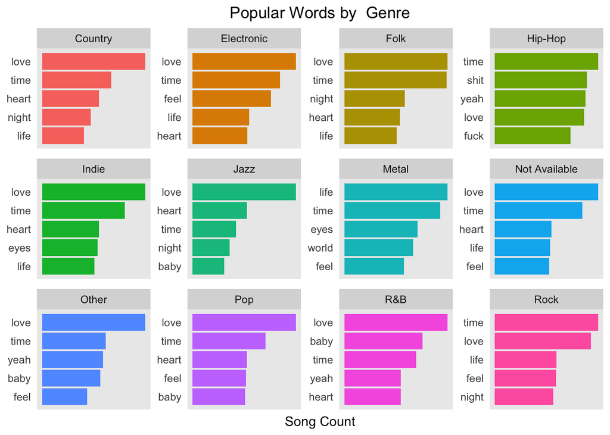

## Popular words via TFIDF apporach

TFIDF is introduced to find the important word. In this way, the weight of general words has been reduced.

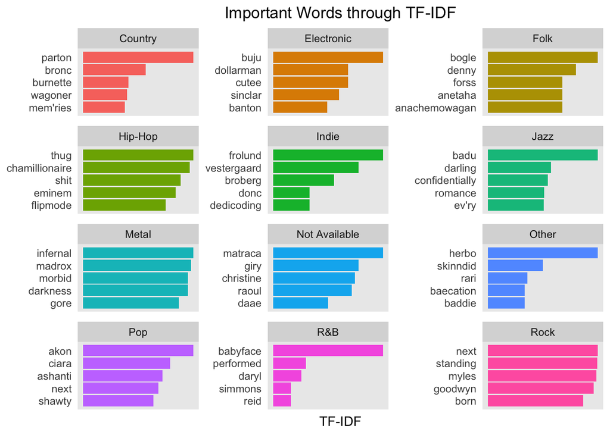

## What kind of emotion these lyrics have?

Sentiment analysis is processed to detect the different emotions which these songs have among genre. According to the plot, Country, Electronic, Folk, Jazz and Pop have more positive words. That’s why these music always convey positive feelings. However, Metal and Hip-hop have more negative words. Metal,especially, its negative word weigh much more than positive one. Rock music tends to have a mixed feeling with richful both positive and negative lyrics.

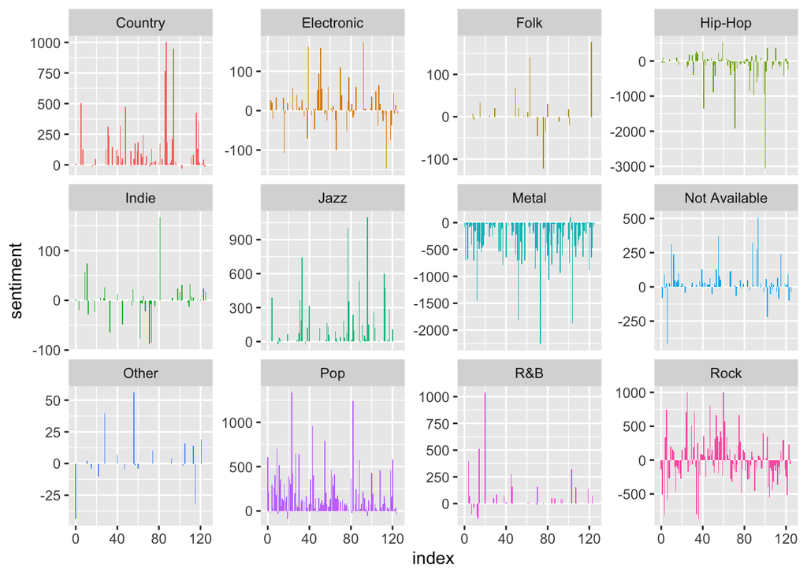

# Summary

By processing the exploratory data anlysis, sentiment analysis, we can get some conclusion among these genres in this data set.